# Assignment 3

Liu Hongtao

[output not shown]

### Machine Learning for Text

In this assignment, you will use R to understand and apply document classification and supervised scaling using R and **quanteda**.

1. **(3 points) Classifying movie reviews, Part 1**. We will start with a classic computer science dataset of movie reviews, [(Pang and Lee 2004)](http://www.cs.cornell.edu/home/llee/papers/cutsent.pdf). The movies corpus has an attribute `Sentiment` that labels each text as either `pos` or `neg` according to the original imdb.com archived newspaper review star rating. We will begin by examining the conditional probabilities at the word level.
1. Load the movies dataset and examine the attributes:

```r
#devtools::install_github("quanteda/quanteda.corpora")
require(quanteda, warn.conflicts = FALSE, quietly = TRUE)
data(data_corpus_movies, package = "quanteda.corpora")
summary(data_corpus_movies, 10)
## Warning in nsentence.character(object, ...): nsentence() does not correctly
## count sentences in all lower-cased text
## Corpus consisting of 2000 documents, showing 10 documents:
##
##             Text Types Tokens Sentences Sentiment   id1   id2
##  neg_cv000_29416   354    841         9       neg cv000 29416
##  neg_cv001_19502   156    278         1       neg cv001 19502
##  neg_cv002_17424   276    553         3       neg cv002 17424
##  neg_cv003_12683   314    564         2       neg cv003 12683
##  neg_cv004_12641   380    842         2       neg cv004 12641
##  neg_cv005_29357   328    749         1       neg cv005 29357
##  neg_cv006_17022   331    643         5       neg cv006 17022
##   neg_cv007_4992   325    676         6       neg cv007  4992
##  neg_cv008_29326   441    797        10       neg cv008 29326
##  neg_cv009_29417   401    965        23       neg cv009 29417
##
## Source: http://www.cs.cornell.edu/people/pabo/movie-review-data/
## Created: Sat Nov 15 18:43:25 2014
## Notes:
```

2. What is the overall probability of the class `pos` in the corpus? Are the classes balanced? (Hint: Use `table()` on the docvar of `Sentiment`.)

```r
length(which(docvars(data_corpus_movies)$Sentiment == "pos")) / length(docvars(data_corpus_movies)$Sentiment)
## [1] 0.5
table(docvars(data_corpus_movies)$Sentiment)
##
##  neg  pos
## 1000 1000
```

**The overall probability of the class `pos` in the corpus is 0.5, the classes are balanced.**

3. Make a dfm from the corpus, grouping the documents by the `Sentiment` docvar.

Words with very low overall frequencies in a corpus of this size are unlikely to be good general predictors. Remove words that occur less than twenty times using `dfm_trim`.

```r
dfmd <- dfm(data_corpus_movies, remove_punct=TRUE, remove=c(stopwords("english")), groups ="Sentiment")
dfmd <- dfm_trim(dfmd, min_termfreq = 20)
```

4. Calculate the word-level likelihoods for each class, from the reduced dfm. (This is the probability of a word given the class `pos` and `neg`.) What are the word likelihoods for `"good"` and “`great`”? What do you learn? Use `kwic()` to find out the context of `"good"`.

Clue: you don’t have to compute the probabilities by hand. You should be able to obtain them using `dfm_weight`.

```r
dfm_weight(dfmd, scheme = "prop")[,c("good", "great")]
## Document-feature matrix of: 2 documents, 2 features (0.0% sparse).
## 2 x 2 sparse Matrix of class "dfm"
##      features
## docs         good       great
##   neg 0.004288506 0.001502875
##   pos 0.004049174 0.002525218

head(kwic(data_corpus_movies, pattern = "good", window = 10), 10)
##
##  [neg_cv000_29416, 127]
##  [neg_cv000_29416, 599]
##  [neg_cv001_19502, 241]
##  [neg_cv003_12683, 515]
##  [neg_cv004_12641, 832]
##  [neg_cv005_29357, 227]
##  [neg_cv005_29357, 261]
##  [neg_cv006_17022, 569]
##   [neg_cv011_13044, 12]
##    [neg_cv016_4348, 99]
##
##               ( lost highway& memento), but there are | good |
##        , would make more sense. the actors are pretty | good |
##   robot design, some schnazzy cgi, and the occasional | good |
##      strain through too much of this mess to find the | good |
##                genre are. if you're in the mood for a | good |
##           . but that still does not make for a really | good |
##  walk on the surface without breathing gear( which is | good |
##   later it's the turn of joaquin phoenix( who's quite | good |
##              garofalo in a romantic comedy-- it was a | good |
##     people have e-mailed me too, saying clueless is a | good |
##
##  and bad ways of making all types of films,
##  for the most part, although wes bentley just seemed
##  gore shot, like picking into someone's brain. so
##  . aside from the fact that children will probably be
##  suspense film, though, stake out something else.
##  science fiction experience. ghosts of mars takes place in
##  for the film's budget). it is never mentioned
##  and by far the film's most interesting character as adult
##  idea a couple years ago with the truth about cats
##  movie and that i'm the only one who doesn't like
```

**The word likehood of good is (neg: 0.00429, pos:0.00405), of great is (neg:0.00150, pos:0.00253), suggesting that the word score of good is slightly negative (-1*0.00429 + 1* 0.00405 = -0.00024), word score of great is positive. When I take look of “good” context, I think people tend to use “good” to describe the things they accepted in a movie, and then mainly critisized other things. This may be a reason why “good” is slightly negative in word score.**

```r
set.seed(1234)  # use this just before the command below
moviesShuffled <- corpus_sample(data_corpus_movies, size = 2000)
#summary(moviesShuffled)
```

Next, make a dfm from the shuffled corpus, and make training labels. In this case, we are using 1500 training labels, and leaving the remaining 500 unlabelled to use as a test set. We will also trim the dataset to remove rare features.

```r
smp <- sample(c("train", "test"), size=2000,
               c(1500, 500), replace=TRUE)
train <- which(smp=="train")
test <- which(smp=="test")

dfmnb <- dfm(moviesShuffled, remove_punct=TRUE, remove=c(stopwords("english")))
dfmnb <- dfm_trim(dfmnb, min_termfreq = 20)
```

2. Now, run the training and testing commands of the Naive Bayes classifier, and compare the predictions for the documents with the actual document labels for the test set using a confusion matrix.

```r
# training Naive Bayes model
nb <- textmodel_nb(dfmnb[train,], docvars(moviesShuffled, "Sentiment")[train])
# predicting labels for test set
preds <- predict(nb, newdata = dfmnb[test,])
# computing the confusion matrix
(cm <- table(preds, docvars(moviesShuffled, "Sentiment")[test]))
##
## preds neg pos
##   neg 230  53
##   pos  40 176
```

3. Compute the following statistics for the last classification. Use this code for starters:

```r
precrecall <- function(mytable, verbose=TRUE) {
    truePositives <- mytable[1,1]
    falsePositives <- sum(mytable[1,]) - truePositives
    falseNegatives <- sum(mytable[,1]) - truePositives
    precision <- truePositives / (truePositives + falsePositives)
    recall <- truePositives / (truePositives + falseNegatives)
    if (verbose) {
        print(mytable)
        cat("\n precision =", round(precision, 2),
            "\n    recall =", round(recall, 2), "\n")
    }
    invisible(c(precision, recall))
}
```

Hint: Computing precision and recall is not the same if we are considering the “true positive” to be predicting positive for a true positive, versus predicting negative for a true negative. Since the factors of `Sentiment` are ordered alphabetically, and since the table command puts lower integer codes for factors first, `movtable` by default puts the (1,1) cell as the case of predicting negative reviews as the “true positive”, not predicting positive reviews. To get the positive-postive prediction you will need to reverse index it, e.g. `movTable[2:1, 2:1]`.

1. precision and recall, *for the positive category prediction*;

```r
precrecall(cm[2:1, 2:1])
##
## preds pos neg
##   pos 176  40
##   neg  53 230
##
##  precision = 0.81
##     recall = 0.77
```

2. accuracy.

```r
sum(diag(cm)) / sum(cm)
## [1] 0.8136273
```

4. Extract the posterior class probabilities of the words `good` and `great`. Do the results confirm your previous finding? Clue: look at the documentation for `textmodel_nb()` for how to extract the posterior class probabilities.

```r
nb$PcGw[,c("good", "great")]
##        features
## classes      good     great
##     neg 0.5214303 0.3851222
##     pos 0.4785697 0.6148778
```

**Yes, the result confirms my previous finding** 3. **(3 points) Classifying movie reviews, Part 3**

1. Run the classification task using a lasso regression through the `cv_glmnet()` function in the `glmnet` package. Then, show the graph with the cross-validated performance of the model based on the number of features included. You should find a curvilinear pattern. Why do you think this pattern emerges?

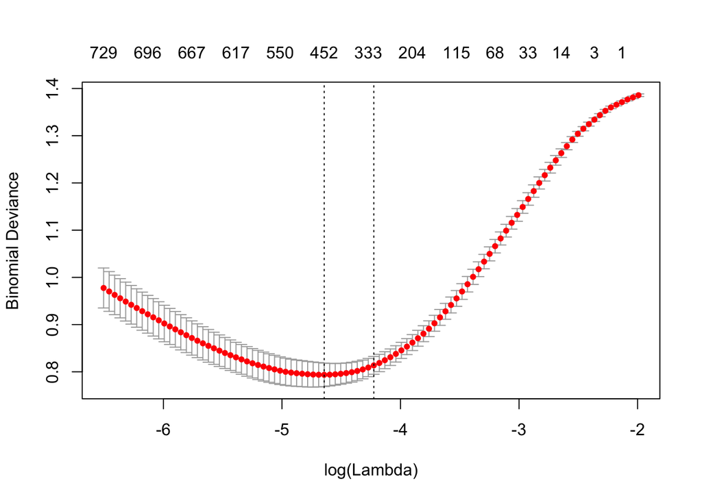

```r
# install.packages("glmnet")
library(glmnet)
## Loading required package: Matrix
## Loading required package: foreach
## Loaded glmnet 2.0-16

lasso <- cv.glmnet(x=dfmnb[train,], y=docvars(moviesShuffled, "Sentiment")[train],
                   alpha=1, nfolds=5, family="binomial")
plot(lasso)
```

**I think this pattern emerges because in the beginning the model is overfitted, we need 333 features to predict** b. Predict the scores for the remaining 500 reviews in the test set and then compute precision and recall for the positive category, the F1 score, and the accuracy. Do the results improve?

```r
pred <- predict(lasso, dfmnb[test,], type="class")
(cm <- table(pred, docvars(moviesShuffled, "Sentiment")[test]))
##
## pred  neg pos
##   neg 216  39
##   pos  54 190

# precision and recall
precrecall(cm[2:1, 2:1])
##
## pred  pos neg
##   pos 190  54
##   neg  39 216
##
##  precision = 0.78
##     recall = 0.83
# accuracy
sum(diag(cm)) / sum(cm)
## [1] 0.8136273

#the F1 score????
```

[output not shown]

[output not shown]

```r
# extracting coefficients
best.lambda <- which(lasso$lambda==lasso$lambda.1se)
beta <- lasso$glmnet.fit$beta[,best.lambda]

## identifying predictive features
df <- data.frame(coef = as.numeric(beta),
                ngram = names(beta), stringsAsFactors=F)

df <- df[order(df$coef),]
head(df[,c("coef", "ngram")], n=10)
##            coef        ngram
## 182  -0.8857602        waste
## 4578 -0.7668220        inept
## 1978 -0.7411117         mess
## 1801 -0.7097251       forgot
## 3265 -0.6817205 embarrassing
## 54   -0.6572008   ridiculous
## 4964 -0.6551803    insulting
## 857  -0.5855108    ludicrous
## 3342 -0.5824208       wasted
## 2252 -0.5527475       sloppy
tail(df[,c("coef", "ngram")], n=10)
##           coef        ngram
## 313  0.4332509    hilarious
## 526  0.4450837   refreshing
## 1079 0.4609804    fantastic
## 664  0.5050515 respectively
## 3068 0.5585451    memorable
## 676  0.5901316    perfectly
## 4193 0.6026094  outstanding
## 1605 0.6194761         ease
## 3820 0.6683589        flaws
## 3782 0.9038015     captures
```

4. **(3 points) Classifying amicus briefs using Naive Bayes.**

This exercise uses *amicus curiae* briefs from US Supreme Court cases on affirmative action in college admissions. [(Evans et al 2007)](http://onlinelibrary.wiley.com/doi/10.1111/j.1740-1461.2007.00113.x/full). [Amicus curiae](http://en.wikipedia.org/wiki/Amicus_curiae) are persons or organizations not party to a legal case who are permitted by the court to offer it advice in the form of an *amicus brief*. The amicus briefs in this corpus are from an affirmative action case in which an applicant to a university who was denied a place petitioned the Supreme Court, claiming that they were unfairly rejected because of affirmative action policies. *Amicus curiae* could advise the court either in support of the petitioner, therefore opposing affirmative action, or in favour of the respondent — the University— therefore supporting affirmative action.  
We will use the original briefs from the [Bolinger case](http://en.wikipedia.org/wiki/Grutter_v._Bollinger#Case_.28_Supreme_Court_.29) examined by Evans et al (2007) for the training set, and the amicus briefs as the test set.

```r
data(data_corpus_amicus, package = "quanteda.corpora")
summary(data_corpus_amicus, 5)
## Corpus consisting of 102 documents, showing 5 documents:
##
##       Text Types Tokens Sentences trainclass testclass
##    sP1.txt  2384  13878       614          P      <NA>
##    sP2.txt  2674  15715       635          P      <NA>
##    sR1.txt  3336  16144       608          R      <NA>
##    sR2.txt  3021  14359       516          R      <NA>
##  sAP01.txt  1822   7795       228       <NA>        AP
##
## Source: /Users/kbenoit/Dropbox/QUANTESS/quantedaData_kenlocal_gh/* on x86_64 by kbenoit
## Created: Mon Sep 15 09:00:59 2014
## Notes:
```

The first four texts will be our training set - these are already set in the docvars to the `amicusCorpus` object.

```r
# set training class
trainclass <- docvars(data_corpus_amicus, "trainclass")
# set test class
testclass  <- docvars(data_corpus_amicus, "testclass")
test <- is.na(testclass)== FALSE
```

1. Construct a dfm, and then predict the test class values using the Naive Bayes classifer.

```r
dfmam <- dfm(data_corpus_amicus, remove_punct=TRUE, remove=c(stopwords("english")))
dfmam <- dfm_trim(dfmam, min_termfreq = 20)
#dfmtest <- dfm(as.character(testclass), remove_punct=TRUE, remove=c(stopwords("english")))
#dfmtest <- dfm_trim(dfmtest, min_termfreq = 20)

# training Naive Bayes model
nb <- textmodel_nb(dfmam, trainclass)
# predicting labels for test set
preds <- predict(nb, dfmam[test])

(cm <- table(preds, docvars(data_corpus_amicus, "testclass")[test]))
##
## preds AP AR
##     P 13  4
##     R  6 75
```

2. Compute accuracy, precision, and recall for both categories

```r
# precision and recall for AR
precrecall(cm[2:1, 2:1])
##
## preds AR AP
##     R 75  6
##     P  4 13
##
##  precision = 0.93
##     recall = 0.95
# accuracy
sum(diag(cm)) / sum(cm)
## [1] 0.8979592
#precision and recall for AP
precrecall(cm)
##
## preds AP AR
##     P 13  4
##     R  6 75
##
##  precision = 0.76
##     recall = 0.68
```

4. Now rerun steps 2-3 after weighting the dfm using *tf-idf*, and see if this improves prediction. What do you find?

```r
dfmam <- dfm_tfidf(dfmam)

# training Naive Bayes model
nb <- textmodel_nb(dfmam, trainclass)
# predicting labels for test set
preds <- predict(nb, dfmam[test])
(cm <- table(preds, docvars(data_corpus_amicus, "testclass")[test]))
##
## preds AP AR
##     P 16 15
##     R  3 64
# precision and recall For AR
precrecall(cm[2:1, 2:1])
##
## preds AR AP
##     R 64  3
##     P 15 16
##
##  precision = 0.96
##     recall = 0.81
precrecall(cm)
##
## preds AP AR
##     P 16 15
##     R  3 64
##
##  precision = 0.52
##     recall = 0.84
# accuracy
sum(diag(cm)) / sum(cm)
## [1] 0.8163265
```

**The tf-idf weighting does not really improve the prediction, as the accuracy and recall decrease significantly when the precision improves a little bit. Its prediction give clearly more “P” calss than before, so the weighting changes a lot. The result for Ap class also does not improve clearly, as the recall goes up to 0.84, while the precision goes down to 0.52**